# Project 1, group 15669, code section

- Date: 6/30/2026
- Aim: collaboration on project 1
- Authors:
  - Yingzi Bu
  - Trinh Bang Pham
  - Javaria Gull

# Problem 1

## Question 1a

Given the difference between the two models, we could get

$$\mu_i = \delta z_i + \epsilon_i$$

Thus if $\epsilon_i$ satisfies the standard assumptions $E (\epsilon_i | x_i, w_i, z_i) = 0$, thus the expectation

$$E(\mu_i | x_i, w_i) = \delta E (z_i | x_i, w_i) + E (\epsilon_i | x_i, w_i) = \delta E (z_i | x_i, w_i)$$

which is generally not 0. Therefore, $\mu_i$ may be correlated with the regressors.

## Question 1b

Given $x \perp w$ and for variables $\tilde{x}_i = x_i - \bar{x}, \tilde{w}_i = w_i - \bar{w}, \tilde{y}_i = y_i - \bar{y}$, we have

$$\sum_i \tilde{x}_i \tilde{w}_i = 0$$

Using the model (2), which means $y_i = \alpha + \beta x_i + \gamma w_i + \mu_i$, to minimize $\sum_i (\tilde{y}_i - \beta \tilde{x}_i - \gamma \tilde{w}_i)^2$, first derivative for $\beta$

$$ \begin{aligned} \frac{\partial}{\partial \beta} \sum_i (\tilde{y}_i - \beta \tilde{x}_i - \gamma \tilde{w}_i) \tilde{x}_i & = 0 \\ \sum_i \tilde{x}_i \tilde{y}_i - \hat{\beta} \sum_i \tilde{x}_i^2 - \hat{\gamma} \sum_i \tilde{x}_i \tilde{w}_i & = 0, \text{given} \sum_i \tilde{x}_i \tilde{w}_i = 0, \text{thus} \\ \sum_i \tilde{x}_i \tilde{y}_i - \hat{\beta} \sum_i \tilde{x}_i^2 & = 0 \\ \hat{\beta} = \frac{\sum_i \tilde{x}_i \tilde{y}_i}{\sum_i \tilde{x}_i^2} = \frac{\sum_i (x_i - \bar{x}) (y_i - \bar{y}) }{\sum_i (x_i - \bar{x})^2 } \end{aligned} $$

Similarly for first derivative to $\gamma$ we have

$$\hat{\gamma} = \frac{\sum_i \tilde{w}_i \tilde{y}_i }{\sum_i \tilde{w}_i^2 } = \frac{ \sum_i (w_i - \bar{w}) (y_i - \bar{y}) }{\sum_i (w_i - \bar{w})^2 } $$

## Question 1c

the true model is model 1, after demeaning we have

$$\tilde{y}_i = \beta \tilde{x}_i + \gamma \tilde{w}_i + \delta \tilde {z}_i + \tilde{\epsilon}_i $$

Given that from model 2

$$\hat{\gamma} = \frac{\sum_i \tilde{w}_i \tilde{y}_i }{\sum_i \tilde{w}_i^2 } = \frac{ \sum_i \tilde{w}_i (\beta \tilde{x}_i + \gamma \tilde{w}_i + \delta \tilde {z}_i + \tilde{\epsilon}_i ) }{\sum_i \tilde{w}^2 } = \frac{\beta \sum_i \tilde{w}_i \tilde{x}_i + \gamma \sum_i \tilde{w}_i^2 + \delta \sum_i \tilde{w}_i \tilde{z}_i + \sum \tilde{w}_i \tilde{\epsilon}_i }{\sum_i \tilde{w}^2 } $$

and given $x \perp w$, which means $\sum_i \tilde{w}_i \tilde{x}_i = 0$, thus

$$\hat{\gamma} = \frac{\beta \sum_i \tilde{w}_i \tilde{x}_i + \gamma \sum_i \tilde{w}_i^2 + \delta \sum_i \tilde{w}_i \tilde{z}_i + \sum \tilde{w}_i \tilde{\epsilon}_i }{\sum_i \tilde{w}^2 } = \gamma + \delta \frac{\sum_i \tilde{w}_i \tilde{z}_i }{\sum_i \tilde{w}^2 } + \frac{\sum_i \tilde{w}_i \tilde{\epsilon}_i}{\sum_i \tilde{w}^2 } $$

If the error terms $\epsilon$ satisfies the standard assumptions $E(\epsilon_i | x_i, w_i, z_i) = 0$, then

$$E(\frac{\sum_i \tilde{w}_i \tilde{\epsilon}_i}{ \sum_i \tilde{w}_i^2} | x, w, z) = 0$$

then

$$E(\hat{\gamma} | x, w, z) = \gamma + \delta \frac{\sum_i \tilde{w}_i \tilde{z}_i }{\sum_i \tilde{w}^2 }$$

thus the bias is

$$\delta \frac{\sum_i \tilde{w}_i \tilde{z}_i }{\sum_i \tilde{w}^2 } = \delta \frac{\text{Cov}(w,z)}{\text{Var}(w)} $$

## Question 1d

The difference between model 1 and model 2 is the error term

$$\mu_i = \delta z_i + \epsilon_i $$

thus if the two models are the same, variable $z_i$ should be part of the error term instead of influencing independently the prediction.

Let $\mathbf{X} = [1, x, w]$ and $\mathbf{b} = [\alpha, \beta, \gamma]^\top$, model 1 is

$$\mathbf{y} = \mathbf{X}\mathbf{b} + \delta z + \epsilon$$

while model 2 is

$$\mathbf{y} = \mathbf{X}\mathbf{b} + \mu$$

For model 2, the OLS estimator is

$$\hat{\mathbf{b}} = (\mathbf{X}^\top \mathbf{X})^{-1} \mathbf{X}^\top \mathbf{y}$$

and substitute the model 1 in the equation above to get

$$\hat{\mathbf{b}} = (\mathbf{X}^\top \mathbf{X})^{-1} \mathbf{X}^\top \mathbf{y} = (\mathbf{X}^\top \mathbf{X})^{-1} \mathbf{X}^\top (\mathbf{X}\mathbf{b} + \delta z + \epsilon) = \mathbf{b} + \delta (\mathbf{X}^\top \mathbf{X})^{-1} \mathbf{X}^\top z + (\mathbf{X}^\top \mathbf{X})^{-1} \mathbf{X}^\top \epsilon$$

Thus, to make model 1 and model 2 the same, we have to let

$$\delta (\mathbf{X}^\top \mathbf{X})^{-1} \mathbf{X}^\top z = 0$$

Several options:

1. $\delta = 0$ will make the extra term = 0
2. $\mathbf{X}^\top z = 0$, which means $z_i$ is orthogonal to all included regressors in model 2 (i.e., the intercept, $x_i$ and $w_i$). In other words

$$\sum_i z_i = 0, \sum_i \tilde{x}_i \tilde{z}_i = 0, \sum_i \tilde{w}_i \tilde{z}_i = 0$$

where

$$\tilde{x}_i = x_i - \bar{x}, \tilde{w}_i = w_i - \bar{w}, \tilde{z}_i = z_i - \bar{z}$$

## Question 1e

$$y_i = a + b x_i + c z_i + e_i$$

let $x_i \sim N(0, 1), e_i \sim N(0, 1)$,

$z_i$ is correlated with $x_i$, thus $\hat{b}_{model2} \rightarrow b + c \frac{\text{Cov} (X, Z)}{\text{Var} (X)}$

different funcs for relationship between $x_i$ and $z_i$

1. $z_i = \rho x_i + \sqrt{1 - \rho^2} u_i, u_i \sim N(0, 1)$, $\hat{b}_{model2} \approx b + c \rho $
2. $z_i = \rho x_i^2$, $cov(X, Z) = cov(X, \rho X^2) = \rho E[X^3] = 0$, thus $\hat{b}_{model2} \approx b$
3. $z_i = \rho x_i^3$, $cov(X, Z) = \rho E[X^4] = \rho * (4-1)!! = 3 \rho$, thus $\hat{b}_{model2} \approx b + 3 \rho $

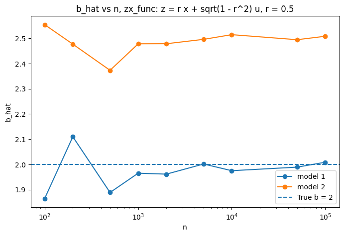

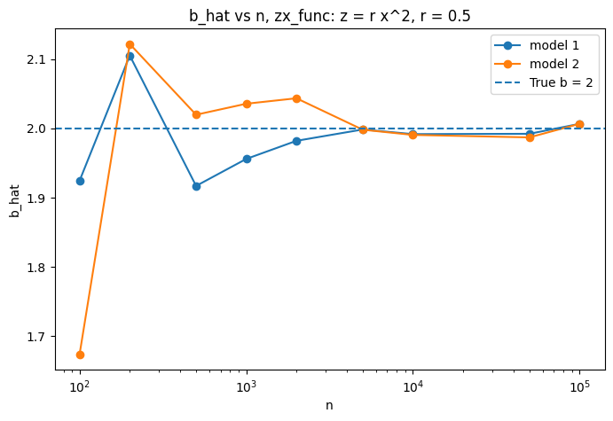

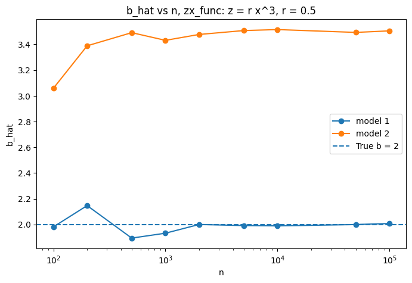

```python
import numpy as np
import pandas as pd
import statsmodels.api as sm
import matplotlib.pyplot as plt
import seaborn as sns

a, b, c, r = 1, 2, 1, 0.5

def run_sim(n, seed = 42, zx_func=1,
            a=a, b=b, c=c, r=r):
    np.random.seed(seed)
    X = np.random.normal(0, 1, n)
    e = np.random.normal(0, 1, n)
    def get_z(zx_func=1):

        if zx_func == 1:
            Z = r * X + np.sqrt(1 - r**2) * np.random.normal(0, 1, n)
        elif zx_func == 2:
            Z = r * X**2
        elif zx_func == 3:
            Z = r * X ** 3
        return Z

    Z = get_z(zx_func)
    Y = a + b * X + c * Z + e

    # model 1: Y ~ X + Z
    X_full = sm.add_constant(pd.DataFrame({'X': X, 'Z': Z}))
    model1 = sm.OLS(Y, X_full).fit()

    # model 2: Y ~ X
    X_omit = sm.add_constant(pd.DataFrame({'X': X}))
    model2 = sm.OLS(Y, X_omit).fit()

    return model1, model2


func_dict = {1: rf'z = r x + sqrt(1 - r^2) u, r = {r}',
             2: rf'z = r x^2, r = {r}',
             3: rf'z = r x^3, r = {r}'}

for zx_func in func_dict.keys():

    results = []
    for n in [100, 200, 500, 1000, 2000, 5000, 10000, 50000, int(1e5)]:
        # print(f'n = {n}')
        model1, model2 = run_sim(n, zx_func=zx_func)
        results.append({
            'n': n,
            'model1_b_hat': model1.params['X'],
            'model2_b_hat': model2.params['X'],
        })
    result_df = pd.DataFrame(results)
    result_df

    plt.figure(figsize=(8,5))
    plt.plot(result_df['n'], result_df['model1_b_hat'],
             marker='o', label='model 1')
    plt.plot(result_df['n'], result_df['model2_b_hat'],
             marker='o', label='model 2')
    plt.xlabel('n')
    plt.xscale('log')
    plt.ylabel('b_hat')
    plt.axhline(b, linestyle='--', label=f'True b = {b}')
    plt.title(f'b_hat vs n, zx_func: {func_dict[zx_func]}')
    plt.legend()
    plt.show()
    plt.close()
```

When Z is correlated with X, the coefficient on X absorbs part of the effect of Z. As the sample size increases, the estimate from model 1 [correct model] converges to the true coefficient, while the model 2 converges to a biased value. Increasing sample size makes the model 2 [omitted model] estimate more stably wrong, unless X and Z are not correlated i.e. cov(X, Z) = 0.

# Problem 2

## Question 2a

Regression models can be sensitive to outliers since the fitted coefficients are chosen by minimizing the sum of squared residuals [e.g. shown in Problem 1]. Since residuals are squared, observations with unusually large errors will have large weight in the estimation, and these extreme observations can pull the fitted regression line toward themselves. Even a few abnormal observations can change the estimated parameters dramatically, especially when they are extreme outliers. The estimated intercept, slope coefficients, fitted values, residuals etc will be biased, which may lead to misleading conclusions.

Therefore, it is important to check the data visually and if outliers are found, they should be examined to see whether they are data errors, rare yet valid observations, or wrong data.

## Question 2b

A simple model $$ y = a + b x + \epsilon, \epsilon \sim N(0, 1)$$

Will estimate OLS before and after adding some outliers.

```
y = a + b x + e, a = 1, b = 2
OLS on clean data
                            OLS Regression Results
==============================================================================
Dep. Variable:                      Y   R-squared:                       0.789
Model:                            OLS   Adj. R-squared:                  0.789
Method:                 Least Squares   F-statistic:                     3733.
Date:                Tue, 30 Jun 2026   Prob (F-statistic):               0.00
Time:                        05:13:06   Log-Likelihood:                -1461.6
No. Observations:                1000   AIC:                             2927.
Df Residuals:                     998   BIC:                             2937.
Df Model:                           1
Covariance Type:            nonrobust
==============================================================================
                 coef    std err          t      P>|t|      [0.025      0.975]
------------------------------------------------------------------------------
const          0.9989      0.033     30.237      0.000       0.934       1.064
X              2.0221      0.033     61.098      0.000       1.957       2.087
==============================================================================
Omnibus:                        0.016   Durbin-Watson:                   1.909
Prob(Omnibus):                  0.992   Jarque-Bera (JB):                0.000
Skew:                           0.002   Prob(JB):                         1.00
Kurtosis:                       3.001   Cond. No.                         1.01
==============================================================================

Notes:
[1] Standard Errors assume that the covariance matrix of the errors is correctly specified.

OLS on outliers
                            OLS Regression Results
==============================================================================
Dep. Variable:                      Y   R-squared:                       0.400
Model:                            OLS   Adj. R-squared:                  0.399
Method:                 Least Squares   F-statistic:                     666.8
Date:                Tue, 30 Jun 2026   Prob (F-statistic):          4.32e-113
Time:                        05:13:06   Log-Likelihood:                -2005.9
No. Observations:                1003   AIC:                             4016.
Df Residuals:                    1001   BIC:                             4026.
Df Model:                           1
Covariance Type:            nonrobust
==============================================================================
                 coef    std err          t      P>|t|      [0.025      0.975]
------------------------------------------------------------------------------
const          0.9413      0.057     16.646      0.000       0.830       1.052
X              1.2082      0.047     25.822      0.000       1.116       1.300
==============================================================================
Omnibus:                     1185.891   Durbin-Watson:                   1.245
Prob(Omnibus):                  0.000   Jarque-Bera (JB):           214339.486
Skew:                          -5.664   Prob(JB):                         0.00
Kurtosis:                      73.714   Cond. No.                         1.21
==============================================================================

Notes:
[1] Standard Errors assume that the covariance matrix of the errors is correctly specified.
```

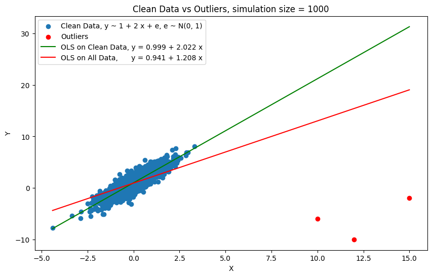

```python
n = 1000
x = np.random.normal(0, 1, n)
e = np.random.normal(0, 1, n)
a = 1
b = 2
y = a + b * x + e
df = pd.DataFrame({
    'X': x,
    'Y': y
})
df_clean = df.copy()
# OLS on clean data
X_clean = sm.add_constant(df['X'])
model_clean = sm.OLS(df['Y'], X_clean).fit()
print(f'y = a + b x + e, a = {a}, b = {b}')
print('OLS on clean data')
print(model_clean.summary())

# OLS on outliers
df_outliers = df.copy()
outliers = pd.DataFrame({
    'X': [12, 15, 10],
    'Y': [-10, -2, -6]
})
df_outliers = pd.concat([df_outliers, outliers], ignore_index=True)

X_outliers = sm.add_constant(df_outliers['X'])
model_outliers = sm.OLS(df_outliers['Y'], X_outliers).fit()
print()
print('OLS on outliers')
print(model_outliers.summary())


plt.figure(figsize=(10, 6))
plt.scatter(df_clean['X'], df_clean['Y'],
            label=f'Clean Data, y ~ {a} + {b} x + e, e ~ N(0, 1)')
plt.scatter(outliers['X'], outliers['Y'], color='red', label='Outliers')
x_grid = np.linspace(df_outliers['X'].min(), df_outliers['X'].max(), 100)
y_grid = model_clean.params['const'] + model_clean.params['X'] * x_grid
a_clean = model_clean.params['const']
b_clean = model_clean.params['X']
plt.plot(x_grid, y_grid, color='green',
         label=f'OLS on Clean Data, y = {a_clean:.3f} + {b_clean:.3f} x')

a_outlier = model_outliers.params['const']
b_outlier = model_outliers.params['X']

y_outlier_line = model_outliers.params['const'] + \
    model_outliers.params['X'] * x_grid
plt.plot(x_grid, y_outlier_line, color='red',
         label=f'OLS on All Data,      y = {a_outlier:.3f} + {b_outlier:.3f} x')

plt.xlabel('X')
plt.ylabel('Y')
plt.legend()
plt.title(f'Clean Data vs Outliers, simulation size = {n}')
plt.show()
plt.close()
```

The clean data were generated from $y = 1 + 2x + \epsilon, \epsilon \sim N(0,1)$. 3 outlier points were added

```
y = a + b x + e, a = 1, b = 2
OLS on clean data
                            OLS Regression Results
==============================================================================
Dep. Variable:                      Y   R-squared:                       0.800
Model:                            OLS   Adj. R-squared:                  0.800
Method:                 Least Squares   F-statistic:                 3.989e+04
Date:                Tue, 30 Jun 2026   Prob (F-statistic):               0.00
Time:                        05:13:22   Log-Likelihood:                -14129.
No. Observations:               10000   AIC:                         2.826e+04
Df Residuals:                    9998   BIC:                         2.828e+04
Df Model:                           1
Covariance Type:            nonrobust
==============================================================================
                 coef    std err          t      P>|t|      [0.025      0.975]
------------------------------------------------------------------------------
const          0.9933      0.010     99.920      0.000       0.974       1.013
X              1.9956      0.010    199.732      0.000       1.976       2.015
==============================================================================
Omnibus:                        0.062   Durbin-Watson:                   2.004
Prob(Omnibus):                  0.970   Jarque-Bera (JB):                0.079
Skew:                          -0.002   Prob(JB):                        0.961
Kurtosis:                       2.987   Cond. No.                         1.01
==============================================================================

Notes:
[1] Standard Errors assume that the covariance matrix of the errors is correctly specified.

OLS on outliers
                            OLS Regression Results
==============================================================================
Dep. Variable:                      Y   R-squared:                       0.742
Model:                            OLS   Adj. R-squared:                  0.742
Method:                 Least Squares   F-statistic:                 2.873e+04
Date:                Tue, 30 Jun 2026   Prob (F-statistic):               0.00
Time:                        05:13:22   Log-Likelihood:                -15417.
No. Observations:               10003   AIC:                         3.084e+04
Df Residuals:                   10001   BIC:                         3.085e+04
Df Model:                           1
Covariance Type:            nonrobust
==============================================================================
                 coef    std err          t      P>|t|      [0.025      0.975]
------------------------------------------------------------------------------
const          0.9837      0.011     87.051      0.000       0.962       1.006
X              1.8815      0.011    169.508      0.000       1.860       1.903
==============================================================================
Omnibus:                    12256.548   Durbin-Watson:                   1.657
Prob(Omnibus):                  0.000   Jarque-Bera (JB):         10981319.432
Skew:                          -5.891   Prob(JB):                         0.00
Kurtosis:                     164.890   Cond. No.                         1.02
==============================================================================

Notes:
[1] Standard Errors assume that the covariance matrix of the errors is correctly specified.
```

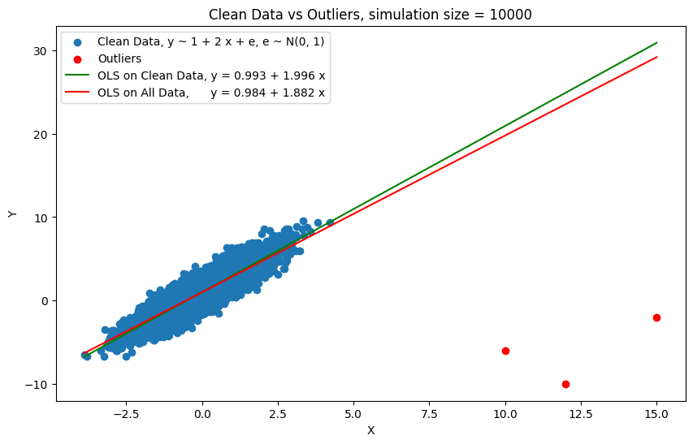

```python
n = 10000
x = np.random.normal(0, 1, n)
e = np.random.normal(0, 1, n)
a = 1
b = 2
y = a + b * x + e
df = pd.DataFrame({
    'X': x,
    'Y': y
})
df_clean = df.copy()
# OLS on clean data
X_clean = sm.add_constant(df['X'])
model_clean = sm.OLS(df['Y'], X_clean).fit()
print(f'y = a + b x + e, a = {a}, b = {b}')
print('OLS on clean data')
print(model_clean.summary())

# OLS on outliers
df_outliers = df.copy()
outliers = pd.DataFrame({
    'X': [12, 15, 10],
    'Y': [-10, -2, -6]
})
df_outliers = pd.concat([df_outliers, outliers], ignore_index=True)

X_outliers = sm.add_constant(df_outliers['X'])
model_outliers = sm.OLS(df_outliers['Y'], X_outliers).fit()
print()
print('OLS on outliers')
print(model_outliers.summary())

plt.figure(figsize=(10, 6))
plt.scatter(df_clean['X'], df_clean['Y'],
            label=f'Clean Data, y ~ {a} + {b} x + e, e ~ N(0, 1)')
plt.scatter(outliers['X'], outliers['Y'], color='red', label='Outliers')
x_grid = np.linspace(df_outliers['X'].min(), df_outliers['X'].max(), 100)
y_grid = model_clean.params['const'] + model_clean.params['X'] * x_grid
a_clean = model_clean.params['const']
b_clean = model_clean.params['X']
plt.plot(x_grid, y_grid, color='green',
         label=f'OLS on Clean Data, y = {a_clean:.3f} + {b_clean:.3f} x')

a_outlier = model_outliers.params['const']
b_outlier = model_outliers.params['X']

y_outlier_line = model_outliers.params['const'] + \
    model_outliers.params['X'] * x_grid
plt.plot(x_grid, y_outlier_line, color='red',
         label=f'OLS on All Data,      y = {a_outlier:.3f} + {b_outlier:.3f} x')

plt.xlabel('X')
plt.ylabel('Y')
plt.legend()
plt.title(f'Clean Data vs Outliers, simulation size = {n}')
plt.show()
plt.close()
```

Sample size was increased from 1000 to 10000. Still, the 3 abnormal observations can still affect the estimated parameters.

Regression analysis should check outliers to obtain reliable conclusion.

## Question 2c

Already shown in Problem 1, we have

$$\hat{\beta} = \frac{\sum_{i=1}^n (x_i - \bar{x}) (y_i - \bar{y}) }{\sum_{i=1}^n (x_i - \bar{x})^2 } $$

Let $A = \sum_{i=1}^{n-1} x_i, B = \sum_{i=1}^{n-1} x_i^2$

Since the first $n-1$ observations have $y_i = 0$, $\sum_{i=1}^n x_i y_i = \sum_{i=1}^{n-1} x_i * 0 + x_n y_n = x_n y_n$

$\bar{x} = \frac{A + x_n}{n}, \bar{y} = \frac{y_n}{n}$

Thus

$$ \begin{aligned} \sum_{i=1}^n (x_i - \bar{x}) (y_i - \bar{y})&= \sum_{i=1}^n x_i y_i - n \bar{x} \bar{y} \\ & = x_n y_n - n (\frac{A + x_n}{n}) (\frac{y_n}{n}) \\ & = x_n y_n - \frac{(A + x_n) y_n}{n} \\ & = \frac{n x_n y_n - A y_n - x_n y_n }{n} \end{aligned} $$$$ \begin{aligned} \sum_{i=1}^n (x_i - \bar{x})^2 & = \sum_{i=1}^n x_i^2 - n \bar{x}^2 \\ & = B + x_n^2 - n (\frac{A + x_n}{n})^2 \\ & = B + x_n^2 - \frac{(A + x_n)^2}{n} \\ & = \frac{ nB + n x_n^2 - A^2 - 2A x_n - x_n^2 }{n} \end{aligned} $$

Thus

$$ \begin{aligned} \hat{\beta} & = \frac{n x_n y_n - A y_n - x_n y_n }{ nB + n x_n^2 - A^2 - 2A x_n - x_n^2 } \\ & = \frac{ y_n [(n-1)x_n - A] }{ (n-1)x_n^2 - 2A x_n + nB - A^2} \\ & = \frac{y_n}{x_n} \frac{ (n-1) - A / x_n }{n-1 - 2A / x_n + (nB - A^2) / (x_n^2)} \end{aligned} $$

As $x_n \rightarrow \infty$,

$$\hat{\beta} \rightarrow \frac{y_n}{x_n} \frac{ (n-1) - 0 }{n-1 - 2 * 0 + (nB - A^2) * 0} = \frac{y_n}{x_n} $$

$\square$

# Problem 3

## Question 3a

Our group number is 15669, thus we will choose `FE-GWP1_model_selection_1.csv`

```python
file_path = '/content/FE-GWP1_model_selection_1.csv'
df = pd.read_csv(file_path)
df.head()
```

|  | Y | X1 | X2 | X3 | X4 | X5 |
| --- | --- | --- | --- | --- | --- | --- |
| 0 | 3.388410 | 0.017954 | -0.800583 | -0.352454 | 2.187210 | 1.014887 |
| 1 | 0.287191 | 0.083057 | -0.597947 | -0.357639 | -1.630284 | 0.221841 |
| 2 | 3.989645 | -0.923437 | -1.386575 | 1.180202 | 0.632606 | -1.576638 |
| 3 | -2.959602 | -0.313775 | 2.955133 | -1.798692 | -2.117621 | 0.159291 |
| 4 | 0.529773 | 0.388996 | 1.019611 | 0.472062 | 0.590497 | 0.877048 |

### Question 3a check all possible combinations

There are only 5 candidate predictors, thus the exhaustive approach is feasible and will check $2^5 - 1 = 31$ combinations.

```python
import itertools
y = df['Y']
predictors = ['X1', 'X2', 'X3', 'X4', 'X5']

def fit_model(cols):
    X = sm.add_constant(df[list(cols)])
    return sm.OLS(y, X).fit()

rows = []
for k in range(1, len(predictors) + 1):
    for cols in itertools.combinations(predictors, k):
        model = fit_model(cols)
        rows.append({
            'model': ' + '.join(cols),
            'num_pred': k,
            # 'R2': model.rsquared,
            'Adj_R2': model.rsquared_adj,
            'AIC': model.aic,
            'BIC': model.bic
        })

result_df = pd.DataFrame(rows)
top_adj_r2 = result_df.sort_values('Adj_R2', ascending=False).head(5)
top_aic = result_df.sort_values('AIC').head(5)
top_bic = result_df.sort_values('BIC').head(5)

print('Top models by Adjusted R-squared:')
print(top_adj_r2)
print()
print('Top models by AIC:')
print(top_aic)
print()
print('Top models by BIC:')
print(top_bic)
```

```
Top models by Adjusted R-squared:
                     model  num_pred    Adj_R2         AIC         BIC
29       X2 + X3 + X4 + X5         4  0.633974  260.616684  273.642535
30  X1 + X2 + X3 + X4 + X5         5  0.630170  262.592528  278.223549
21            X2 + X3 + X4         3  0.616639  264.291054  274.711735
25       X1 + X2 + X3 + X4         4  0.612991  266.191097  279.216948
23            X2 + X4 + X5         3  0.494796  291.889597  302.310277

Top models by AIC:
                     model  num_pred    Adj_R2         AIC         BIC
29       X2 + X3 + X4 + X5         4  0.633974  260.616684  273.642535
30  X1 + X2 + X3 + X4 + X5         5  0.630170  262.592528  278.223549
21            X2 + X3 + X4         3  0.616639  264.291054  274.711735
25       X1 + X2 + X3 + X4         4  0.612991  266.191097  279.216948
23            X2 + X4 + X5         3  0.494796  291.889597  302.310277

Top models by BIC:
                     model  num_pred    Adj_R2         AIC         BIC
29       X2 + X3 + X4 + X5         4  0.633974  260.616684  273.642535
21            X2 + X3 + X4         3  0.616639  264.291054  274.711735
30  X1 + X2 + X3 + X4 + X5         5  0.630170  262.592528  278.223549
25       X1 + X2 + X3 + X4         4  0.612991  266.191097  279.216948
23            X2 + X4 + X5         3  0.494796  291.889597  302.310277
```

### Queston 3a Forward

```python
def forward_selection(crit='AIC'):
    remaining = predictors.copy()
    selected, history = [], []
    if crit == 'Adj_R2': best_score = -np.inf
    else: best_score = np.inf

    while len(remaining) > 0:
        scores = []
        for col in remaining:
            cols = selected + [col]
            model = fit_model(cols)
            if crit == 'Adj_R2':
                score = model.rsquared_adj
            elif crit=='AIC':
                score = model.aic
            elif crit=='BIC':
                score = model.bic
            scores.append((score, col, cols, model))
        if crit == 'Adj_R2':
            best_candidate = max(scores, key=lambda x: x[0])
            improved = best_candidate[0] > best_score
        else:
            best_candidate = min(scores, key=lambda x: x[0])
            improved = best_candidate[0] < best_score
        if improved:
            best_score, best_col, best_cols, best_model = best_candidate
            selected = best_cols.copy()
            remaining.remove(best_col)

            history.append({
                'selected_model': ' + '.join(best_cols),
                'num_pred': len(best_cols),
                'R2': best_model.rsquared,
                'Adj_R2': best_model.rsquared_adj,
                'AIC': best_model.aic,
                'BIC': best_model.bic
            })
        else:
            break
    return pd.DataFrame(history), fit_model(best_cols)

for crit in ['AIC', 'BIC', 'Adj_R2']:
    print('Forward selection using', crit)
    history, model = forward_selection(crit=crit)
    # print(model.summary())
    print(history)
    print()
```

```
Forward selection using AIC
      selected_model  num_pred        R2    Adj_R2         AIC         BIC
0                 X4         1  0.289776  0.282529  325.028687  330.239028
1            X4 + X3         2  0.476928  0.466143  296.442510  304.258021
2       X4 + X3 + X2         3  0.628256  0.616639  264.291054  274.711735
3  X4 + X3 + X2 + X5         4  0.648763  0.633974  260.616684  273.642535

Forward selection using BIC
      selected_model  num_pred        R2    Adj_R2         AIC         BIC
0                 X4         1  0.289776  0.282529  325.028687  330.239028
1            X4 + X3         2  0.476928  0.466143  296.442510  304.258021
2       X4 + X3 + X2         3  0.628256  0.616639  264.291054  274.711735
3  X4 + X3 + X2 + X5         4  0.648763  0.633974  260.616684  273.642535

Forward selection using Adj_R2
      selected_model  num_pred        R2    Adj_R2         AIC         BIC
0                 X4         1  0.289776  0.282529  325.028687  330.239028
1            X4 + X3         2  0.476928  0.466143  296.442510  304.258021
2       X4 + X3 + X2         3  0.628256  0.616639  264.291054  274.711735
3  X4 + X3 + X2 + X5         4  0.648763  0.633974  260.616684  273.642535
```

### Question 3a backward

```python
def backward_selection(crit='AIC'):
    selected = predictors.copy()
    history = []
    current_res = fit_model(selected)
    if crit == 'AIC': best_score = current_res.aic
    elif crit == 'BIC': best_score = current_res.bic
    elif crit == 'Adj_R2': best_score = current_res.rsquared_adj
    history.append({
        'selected_model': ' + '.join(selected),
        # 'num_pred': len(selected),
        # 'R2': current_res.rsquared,
        'Adj_R2': current_res.rsquared_adj,
        'AIC': current_res.aic,
        'BIC': current_res.bic
    })
    improved = True
    while len(selected) > 1 and improved:
        scores = []
        for col in selected:
            candidate_predictors = [v for v in selected if v != col]
            model = fit_model(candidate_predictors)
            if crit == 'AIC':
                score = model.aic
            elif crit == 'BIC':
                score = model.bic
            elif crit == 'Adj_R2':
                score = model.rsquared_adj
            scores.append((score, col, candidate_predictors, model))
        if crit == 'Adj_R2':
            best_candidate = max(scores, key=lambda x: x[0])
            improved = best_candidate[0] > best_score
        else:
            best_candidate = min(scores, key=lambda x: x[0])
            improved = best_candidate[0] < best_score
        if improved:
            best_score, best_col, best_cols, best_model = best_candidate
            selected = best_cols.copy()
            history.append({
                'selected_model': ' + '.join(best_cols),
                # 'num_pred': len(best_cols),
                # 'R2': best_model.rsquared,
                'Adj_R2': best_model.rsquared_adj,
                'AIC': best_model.aic,
                'BIC': best_model.bic
            })
        else:
            break
    return pd.DataFrame(history), fit_model(selected)

for crit in ['AIC', 'BIC', 'Adj_R2']:
    print('Backward selection using', crit)
    history, model = backward_selection(crit=crit)
    # print(model.summary())
    print(history)
    print()
```

```
Backward selection using AIC
           selected_model    Adj_R2         AIC         BIC
0  X1 + X2 + X3 + X4 + X5  0.630170  262.592528  278.223549
1       X2 + X3 + X4 + X5  0.633974  260.616684  273.642535

Backward selection using BIC
           selected_model    Adj_R2         AIC         BIC
0  X1 + X2 + X3 + X4 + X5  0.630170  262.592528  278.223549
1       X2 + X3 + X4 + X5  0.633974  260.616684  273.642535

Backward selection using Adj_R2
           selected_model    Adj_R2         AIC         BIC
0  X1 + X2 + X3 + X4 + X5  0.630170  262.592528  278.223549
1       X2 + X3 + X4 + X5  0.633974  260.616684  273.642535
```

```python
selected_model = fit_model(['X2', 'X3', 'X4', 'X5'])
print(selected_model.summary())
print(selected_model.pvalues)
```

```
                            OLS Regression Results
==============================================================================
Dep. Variable:                      Y   R-squared:                       0.649
Model:                            OLS   Adj. R-squared:                  0.634
Method:                 Least Squares   F-statistic:                     43.87
Date:                Tue, 30 Jun 2026   Prob (F-statistic):           8.29e-21
Time:                        06:34:38   Log-Likelihood:                -125.31
No. Observations:                 100   AIC:                             260.6
Df Residuals:                      95   BIC:                             273.6
Df Model:                           4
Covariance Type:            nonrobust
==============================================================================
                 coef    std err          t      P>|t|      [0.025      0.975]
------------------------------------------------------------------------------
const          1.1893      0.089     13.333      0.000       1.012       1.366
X2            -0.5861      0.091     -6.440      0.000      -0.767      -0.405
X3             0.5592      0.091      6.124      0.000       0.378       0.740
X4             0.7105      0.082      8.672      0.000       0.548       0.873
X5            -0.1966      0.083     -2.355      0.021      -0.362      -0.031
==============================================================================
Omnibus:                        4.462   Durbin-Watson:                   1.974
Prob(Omnibus):                  0.107   Jarque-Bera (JB):                3.920
Skew:                           0.473   Prob(JB):                        0.141
Kurtosis:                       3.215   Cond. No.                         1.39
==============================================================================

Notes:
[1] Standard Errors assume that the covariance matrix of the errors is correctly specified.
const    1.753806e-23
X2       4.874019e-09
X3       2.048588e-08
X4       1.132305e-13
X5       2.057440e-02
dtype: float64
```

```python
print(selected_model.params)
```

```
const    1.189339
X2      -0.586083
X3       0.559157
X4       0.710541
X5      -0.196639
dtype: float64
```

### Question 3a summary

All 5 predictors were explored for candidate regression model comparison. First, all possible non-empty subsets of the 5 predictors were used to build the model. All 3 criteria (adjusted R-squared, AIC and BIC) selected the same model X2 + X3 + X4 + X5.

Then forward selection was used. Forward selection added variables in the order of X4, X3, X2, X5 and stopped before adding X1.

Backward selecton begin with all 5 predictors and then removed X1.

Overall, all the approaches showed that the best model is `Y ~ X2 + X3 + X4 + X5` and X1 should be exluded. If including X1, the adjusted R-squared will be slightly reduced and AIC & BIC will both increase. This suggests that X1 does not provide enough additional explanatory power compared with other 4 predictors.

## Question 3b

BIC is more reliable because BIC penalizes unnecessary variables more heavily.

Let the true model

$$M_t: y_i = \alpha + \beta x_i + \epsilon_i$$

and the overfitted model

$$M_o: y_i = \alpha + \beta x_i + \gamma z_i + \mu_i$$

where in reality $\gamma = 0$ so $z_i$ is unnecessary.

Let the maximized log-likelihoods be: $l_t, l_o$, since overfitted model contains true model, we always have $l_o \geq l_t$

The likelihood-ratio statistic is $LR = 2 (l_o - l_t)$. Given $\gamma = 0$, we have $LR \sim \chi_1^2$.

$$\text{AIC} = -2l + 2k$$

The overfitted model has one extra parameter, so AIC choose the overfitted model if

$$-2l_o + 2 (k + 1) < -2 l_t + 2k$$

which is $LR > 2$.

There is always a positive probability that $\chi_1^2 > 2$. This probability does not go to 0 as $n \rightarrow \infty$. Therefore, AIC may keep selecting the unnecessary variable and is not consistent for selecting the true model.

$$\text{BIC} = -2 l + k \log n $$

BIC chooses the larger model if

$$-2 l_o + (k+1) \log n < -2 l_t + k \log n $$

which is $LR > \log n$. When the sample size n increases to infinity, $\log n \rightarrow \infty$, therefore $P(LR > \log n) \rightarrow 0$, so BIC will reject the unnecessary extra predictor with probability approaching 1.

# Problem 4

## Question 4a

age^2 was included because the relationship between age and wage is not likely to be purely linear. Wage usually increase with age and work experience at young ages, but the increase speed may change later in a worker's career. By including both age and age^2, the model allows the effect of age on wage to change as age changes.

## Question 4b

ln wage is used since wages are usually right skewed. A small number of rich people earn very high wages. Taking logs makes it less skewed and reduces the influence of extreme wage values. If often makes the regression relationship closer to linear, and helps stabilize the variance of the error term. Besides, coefficients in a log-wage model are easier to interpret as approximate percentage effects.

## Question 4c

ln wage is used because percentage changes are usually more meaningful than absolute dollar change. E.g. 5 dollar /h increase means different for a worker earning 10 dollar /h than for a worker earning 1000 dollar /h. Using log wage allows to describe the effect of education, age, gender or degree as an approximate percentage change in wage, which is more meaningful when comparing workers with different wage levels.

## Question 4d

All else equal (equal gender, age, and degree status), one additional year of education is associated with $\exp{0.08} - 1 = 8.33\%$ increase in hourly wage.

## Question 4e

Since gender = 1 if Female, 0 if Male, and the coefficient is -0.15, which means that holding education, age, and degree constant, the wage diff is $e^{-0.15} - 1 = -13.9\%$ between gender, which means females are estimated to earn 13.9% lower hourly wage compared to male. However, the t-statistic is -1.5, and $|t| < 1.96$, which means this coefficient is not statistically significant at the 5% level.

Overall, although the point estimate suggests a gender wage gap, the regression does not provide strong statistical evidence to support this.

## Question 4f

$$ \frac{\partial \ln \text{wage}}{\partial \text{age}} = \beta_3 + 2 \beta_4 * \text{age}$$

in which $\beta_3 = 0.19, \beta_4 = -0.002$, thus let

$$\beta_3 + 2 \beta_4 * \text{age} = 0$$

we could have age = 47.5.

Thus the hourly wage reaches its maximum at approx 47.5 years old.

## Question 4g

degree = 1 if master's degree or higher, degree = 0 otherwise. Thus the effect is $e^{0.22} - 1 = 24.6\%$, with t-statistic = 5.50 which is statistically significant.

Workers with a master's degree or higher earn approx 24.6% more per hour than otherwise, and this effect is significant.

## Question 4h

No. If we really use two dummy variables to represent male and female, then for every observation, the two dummy variables will always add up to 1, causing perfect multicollinearity.

# Problem 5

## Question 5a

$$w_t = w_{t-1} + \epsilon_t, w_0 = 0$$

thus $w_1 = w_0 + \epsilon_1 = \epsilon_1$, $w_2 = w_1 + \epsilon_2 = \epsilon_1 + \epsilon_2$ ...

thus $w_t = \epsilon_1 + \cdots + \epsilon_t = \sum_{i=1}^t \epsilon_i$,

Given $X_t = w_t + \eta_t$, thus $X_t = \sum_{i=1}^t \epsilon_i + \eta_t$

$X_t$ is not stationary as $w_t = \sum_{i=1}^t \epsilon_i$ is random walk. The variance grows with time. $\eta_t$ is only an I(0) noise component so it does not remove the random-walk component. Thus $X_t$ is nonstationary and I(1). Similarly, for Y and Z, they both contains $w_t$ and a I(0) white noise component just like X, so all X, Y and Z are nonstationary and I(1).

## Question 5b

There are 2 cointegrated vectors. There are 3 observed series X, Y, Z yet they all have one common stochastic trend, thus the rank is 2.

Consider

$$a X_t + b Y_t + c Z_t = a (w_t + \eta_t) + b (0.5 w_t + \theta_t) + c (-w_t + \chi_t) = (a + 0.5b - c)w_t + a\eta_t + b \theta_t + c \chi_t$$

For this to be stationary,

$$a + 0.5b - c = 0$$

This gives a two-dimensional set of solutions so there are two linearly independent cointegration vectors.

One choice could be (1, -2, 0), the other could be (1, 0, 1).

## Question 5c

```python
file_path = '/content/FE-GWP1_dataset_Prob5.csv'
raw = pd.read_csv(file_path)
if raw.shape[1] == 1:
    rows = []
    with open(file_path, encoding='utf-8-sig') as f:
        for line in f:
            rows.append(line.strip().strip('"').split(","))
    df = pd.DataFrame(rows[1:], columns=rows[0]).astype(float)
else:
    df = raw.copy()

df['Period'] = df['Period'].astype(int)
df.head()
```

|  | Period | X | Y | Z |
| --- | --- | --- | --- | --- |
| 0 | 1 | 0.082217 | 0.577180 | -0.312377 |
| 1 | 2 | 0.078359 | -0.317703 | -0.555119 |
| 2 | 3 | 1.379785 | 0.837258 | -0.991766 |
| 3 | 4 | 2.834353 | 1.689486 | -1.889942 |
| 4 | 5 | 2.284564 | 1.124723 | -2.199465 |

### Question 5c 1. Perform a visual inspection

X, Y, Z do not fluctuate around fixed constant means. They move persistently over time which is consistent with nonstationary behavior.

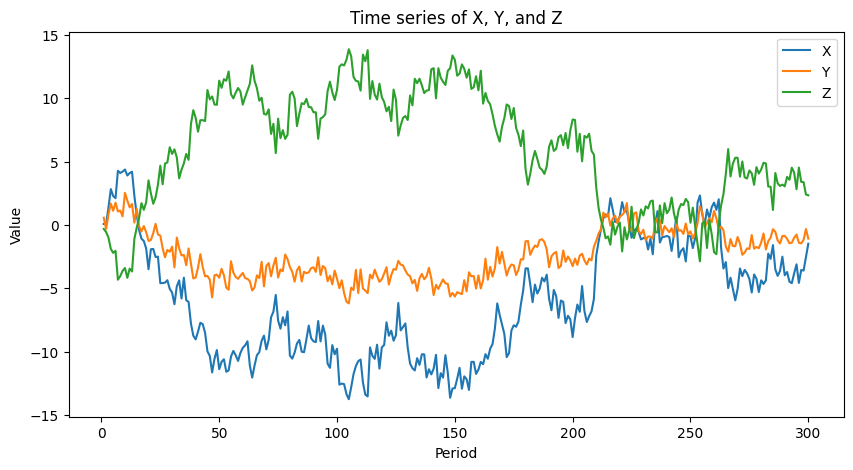

```python
plt.figure(figsize=(10,5))
for col in ['X', 'Y', 'Z']:
    plt.plot(df['Period'], df[col], label=col)
plt.xlabel('Period')
plt.ylabel('Value')
plt.title('Time series of X, Y, and Z')
plt.legend()
plt.show()
plt.close()
```

### Question 5c 2 Unit root testing

```python
from statsmodels.tsa.stattools import adfuller
from statsmodels.tsa.vector_ar.vecm import coint_johansen, select_order, VECM

def adf_test(series, name):
    result = adfuller(series, autolag='AIC')
    return {
        'series': name,
        'ADF stat': result[0],
        'p-value': result[1],
        'used lag': result[2],
    }

adf_results = [adf_test(df[col], col) for col in ['X', 'Y', 'Z']]
adf_df = pd.DataFrame(adf_results)
adf_df
```

|  | series | ADF stat | p-value | used lag |
| --- | --- | --- | --- | --- |
| 0 | X | -2.486236 | 0.118859 | 6 |
| 1 | Y | -2.080296 | 0.252511 | 4 |
| 2 | Z | -1.966677 | 0.301372 | 1 |

```python
diff_results = [adf_test(df[col].diff().dropna(), f'Delta {col}') \
                for col in ['X', 'Y', 'Z']]
diff_df = pd.DataFrame(diff_results)
diff_df
```

|  | series | ADF stat | p-value | used lag |
| --- | --- | --- | --- | --- |
| 0 | Delta X | -10.339658 | 2.706027e-18 | 3 |
| 1 | Delta Y | -12.012434 | 3.158065e-22 | 3 |
| 2 | Delta Z | -22.510537 | 0.000000e+00 | 0 |

Based on p-value, the ADF tests fail to reject the unit-root null for X, Y, Z in levels, but strong reject the unit-root null after first differencing. Therefore, X, Y, and Z are all consistent with being I(1).

```python
data = df[['X', 'Y', 'Z']]
lag_selection = select_order(data, maxlags=10, deterministic='co')
lag_selection.summary()
```

VECM Order Selection (* highlights the minimums)

|  | AIC | BIC | FPE | HQIC |
| --- | --- | --- | --- | --- |
| 0 | -1.916* | -1.726* | 0.1472* | -1.840* |
| 1 | -1.900 | -1.595 | 0.1496 | -1.778 |
| 2 | -1.857 | -1.439 | 0.1561 | -1.690 |
| 3 | -1.822 | -1.289 | 0.1617 | -1.609 |
| 4 | -1.800 | -1.153 | 0.1654 | -1.541 |
| 5 | -1.782 | -1.020 | 0.1685 | -1.477 |
| 6 | -1.792 | -0.9166 | 0.1668 | -1.441 |
| 7 | -1.736 | -0.7461 | 0.1765 | -1.339 |
| 8 | -1.679 | -0.5752 | 0.1870 | -1.237 |
| 9 | -1.629 | -0.4115 | 0.1966 | -1.141 |
| 10 | -1.601 | -0.2693 | 0.2023 | -1.068 |

```python
# the minimum is 0 thus
k_ar_diff = 0

johansen_result = coint_johansen(data, det_order=0, k_ar_diff=k_ar_diff)
trace = pd.DataFrame({
    'H0 rank <=': [0,1,2],
    'Trace stat': johansen_result.lr1,
    '90% crit': johansen_result.cvt[:,0],
    '95% crit': johansen_result.cvt[:,1],
    '99% crit': johansen_result.cvt[:,2]
})
print('Johansen trace test')
display(trace)
print()
maxeig = pd.DataFrame({
    'H0 rank <=': [0,1,2],
    'Max eigen stat': johansen_result.lr2,
    '90% crit': johansen_result.cvm[:,0],
    '95% crit': johansen_result.cvm[:,1],
    '99% crit': johansen_result.cvm[:,2]
})
print('Johansen maximum eigenvalue test')
display(maxeig)
```

```
Johansen trace test
```

|  | H0 rank <= | Trace stat | 90% crit | 95% crit | 99% crit |
| --- | --- | --- | --- | --- | --- |
| 0 | 0 | 435.996086 | 27.0669 | 29.7961 | 35.4628 |
| 1 | 1 | 203.533782 | 13.4294 | 15.4943 | 19.9349 |
| 2 | 2 | 3.510309 | 2.7055 | 3.8415 | 6.6349 |

```
Johansen maximum eigenvalue test
```

|  | H0 rank <= | Max eigen stat | 90% crit | 95% crit | 99% crit |
| --- | --- | --- | --- | --- | --- |
| 0 | 0 | 232.462304 | 18.8928 | 21.1314 | 25.8650 |
| 1 | 1 | 200.023473 | 12.2971 | 14.2639 | 18.5200 |
| 2 | 2 | 3.510309 | 2.7055 | 3.8415 | 6.6349 |

Both the trace and maximum eigenvalue test reject no cointegration and reject at most one cointegrating relation, yet they do not reject at most 2 cointegrating relations at 5% level. Thus, the appropriate cointegration rank is 2.

```python
vecm_model = VECM(data, k_ar_diff=k_ar_diff, coint_rank=2, deterministic='co')
vecm_result = vecm_model.fit()
print(vecm_result.summary())
```

```
Det. terms outside the coint. relation & lagged endog. parameters for equation X
==============================================================================
                 coef    std err          z      P>|z|      [0.025      0.975]
------------------------------------------------------------------------------
const         -0.0052      0.067     -0.077      0.938      -0.137       0.126
Det. terms outside the coint. relation & lagged endog. parameters for equation Y
==============================================================================
                 coef    std err          z      P>|z|      [0.025      0.975]
------------------------------------------------------------------------------
const          0.1274      0.038      3.346      0.001       0.053       0.202
Det. terms outside the coint. relation & lagged endog. parameters for equation Z
==============================================================================
                 coef    std err          z      P>|z|      [0.025      0.975]
------------------------------------------------------------------------------
const          0.0952      0.067      1.411      0.158      -0.037       0.227
                 Loading coefficients (alpha) for equation X
==============================================================================
                 coef    std err          z      P>|z|      [0.025      0.975]
------------------------------------------------------------------------------
ec1           -0.4710      0.098     -4.828      0.000      -0.662      -0.280
ec2            0.2611      0.124      2.101      0.036       0.018       0.505
                 Loading coefficients (alpha) for equation Y
==============================================================================
                 coef    std err          z      P>|z|      [0.025      0.975]
------------------------------------------------------------------------------
ec1            0.1487      0.055      2.687      0.007       0.040       0.257
ec2           -0.9334      0.071    -13.239      0.000      -1.072      -0.795
                 Loading coefficients (alpha) for equation Z
==============================================================================
                 coef    std err          z      P>|z|      [0.025      0.975]
------------------------------------------------------------------------------
ec1           -0.5325      0.098     -5.429      0.000      -0.725      -0.340
ec2           -0.2571      0.125     -2.058      0.040      -0.502      -0.012
          Cointegration relations for loading-coefficients-column 1
==============================================================================
                 coef    std err          z      P>|z|      [0.025      0.975]
------------------------------------------------------------------------------
beta.1         1.0000          0          0      0.000       1.000       1.000
beta.2     -9.669e-17          0          0      0.000   -9.67e-17   -9.67e-17
beta.3         1.0084      0.009    116.849      0.000       0.992       1.025
          Cointegration relations for loading-coefficients-column 2
==============================================================================
                 coef    std err          z      P>|z|      [0.025      0.975]
------------------------------------------------------------------------------
beta.1      4.488e-17          0          0      0.000    4.49e-17    4.49e-17
beta.2         1.0000          0          0      0.000       1.000       1.000
beta.3         0.4157      0.006     65.083      0.000       0.403       0.428
==============================================================================
```

```python
alpha = pd.DataFrame(vecm_result.alpha,
                     index=['Delta X', 'Delta Y', 'Delta Z'],
                     columns=['ec1', 'ec2'])

beta = pd.DataFrame(vecm_result.beta,
                    index=['X', 'Y', 'Z'],
                    columns=['coint_relation_1', 'coint_relation_2'])

print('loading matrix alpha')
display(alpha)
print()
print('cointegration matrix beta')
display(beta)
```

```
loading matrix alpha
```

|  | ec1 | ec2 |
| --- | --- | --- |
| Delta X | -0.470991 | 0.261096 |
| Delta Y | 0.148711 | -0.933446 |
| Delta Z | -0.532503 | -0.257145 |

```
cointegration matrix beta
```

|  | coint_relation_1 | coint_relation_2 |
| --- | --- | --- |
| X | 1.000000e+00 | 4.488177e-17 |
| Y | -9.668857e-17 | 1.000000e+00 |
| Z | 1.008446e+00 | 4.157040e-01 |

The VECM was estimated using cointegration rank r = 2. Thus the estimated cointegrating relationships are approximately

$$X_t + 1.008446 Z_t$$

which is close to $X_t + Z_t$ and

$$Y_t + 0.415704 Z_t$$

which is close to $Y_t + 0.5Z_t$

# Problem 6

## Question 6a

$$Y_t = 0.5 Y_{t-1} + \epsilon_t$$$$ Y_{t-1} = 0.5 Y_{t-2} + \epsilon_{t-1}$$

thus

$$Y_t = 0.5 (0.5 Y_{t-2} + \epsilon_{t-1}) + \epsilon_t = 0.5^2 Y_{t-2} + 0.5 \epsilon_{t-1} + \epsilon_t$$

Again:

$$Y_{t-2} = 0.5 Y_{t-3} + \epsilon_{t-2} $$

thus

$$Y_t = 0.5^2 Y_{t-2} + 0.5 \epsilon_{t-1} + \epsilon_t = 0.5^2 [0.5 Y_{t-3} + \epsilon_{t-2}] + 0.5 \epsilon_{t-1} + \epsilon_t = 0.5^3 Y_{t-3} + 0.5^2 \epsilon_{t-2} + 0.5 \epsilon_{t-1} + \epsilon_t$$

Again:

$$Y_{t-3} = 0.5 Y_{t-4} + \epsilon_{t-3} $$

thus

$$Y_t = 0.5^3 Y_{t-3} + 0.5^2 \epsilon_{t-2} + 0.5 \epsilon_{t-1} + \epsilon_t = 0.5^4 Y_{t-4} + 0.5^3 \epsilon_{t-3} + 0.5^2 \epsilon_{t-2} + 0.5 \epsilon_{t-1} + \epsilon_t$$

Since 0.5 < 1, thus $0.5^k Y_{t-k} \rightarrow 0$ as $k \rightarrow \infty$. Thus MA($\infty$) is

$$Y_t = \epsilon_t + 0.5 \epsilon_{t-1} + 0.5^2 \epsilon_{t-2} + 0.5^3 \epsilon_{t-3} + \cdots$$

The first four terms:

$$\epsilon_t + 0.5 \epsilon_{t-1} + 0.5^2 \epsilon_{t-2} + 0.5^3 \epsilon_{t-3} $$

## Question 6b

For AR(2),

$$Z_t = \phi_1 Z_{t-1} + \phi_2 Z_{t-2} + \epsilon_t$$

the autocorrelations satisfy:

$$\rho_1 = \phi_1 + \phi_2 \rho_1, \rho_2 = \phi_1 \rho_1 + \phi_2$$$$\phi_1 = 0.6, \phi_2 = 0.2$$

thus

$$\rho_1 = 0.6 + 0.2 \rho_1, \rho_2 = 0.6\rho_1 + 0.2$$

thus $\rho_1 = 3/4 = 0.75$, $\rho_2 = 0.6 * 0.75 + 0.2 = 0.65$